# Analisis Runtun Waktu Project Akhir

Analisa data nilai Ekspor Indonesia

1. Install Library yang diperlukan

```r
library(timeSeries)
library(forecast)
library(tseries)
library(dplyr)
library(readxl)
library(lmtest)
```

2. Import Data

```r
DataEkspor <- read_excel("C:/Users/bhayu/Downloads/Data Nilai Ekspor Indonesia tahun 2015-2022.xlsx")
DataEkspor
```

| Tahun | Januari | Februari | Maret | April | Mei | Juni | Juli | Agustus | September | Oktober | November | Desember |
| --- | --- | --- | --- | --- | --- | --- | --- | --- | --- | --- | --- | --- |
| 2015 | 13244876798 | 12172802863 | 13634041965 | 13104596804 | 12754659044 | 13514101879 | 11465779764 | 12726037507 | 12588359371 | 12121740572 | 11122182554 | 11917112382 |
| 2016 | 10581883838 | 11316734189 | 11812127478 | 11689745851 | 11517409126 | 13206122765 | 9649503976 | 12753921321 | 12579750250 | 12743736884 | 13502920383 | 13832355186 |
| 2017 | 13397676588 | 12615980315 | 14718477687 | 13269689618 | 14333859524 | 11661376381 | 13611062499 | 15187990997 | 14580216112 | 15252563526 | 15334735601 | 14864547090 |
| 2018 | 14576277326 | 14132382056 | 15510616703 | 14496238057 | 16198340826 | 12941739832 | 16284719992 | 15865124056 | 14956348234 | 15909072846 | 14851720862 | 14290093210 |
| 2019 | 14028086397 | 12788557132 | 14447789013 | 13068068333 | 14751890718 | 11763353137 | 15238418109 | 14261962734 | 14080108446 | 14881456854 | 13944486957 | 14428818305 |
| 2020 | 13636412654 | 14042089243 | 14031292078 | 12159824545 | 10452625425 | 12006813613 | 13689902559 | 13055281121 | 13956176572 | 14363443251 | 15258422043 | 16539555060 |
| 2021 | 15300168402 | 15255398398 | 18398414762 | 18474131707 | 16908015508 | 18547744864 | 19369596671 | 21443151841 | 20618788618 | 22090984014 | 22845364125 | 22357720668 |
| 2022 | 19173699043 | 20472894279 | 26497477726 | 27322284676 | 21509825822 | 26150115172 | 25563196494 | 27862094371 | 24777175554 | 24728444384 | 24094037088 | NA |

3. Cleaning Data (Mengambil data yang dibutuhkan dan mengubah data menjadi timeseries)

```r
#Hilangkan kolom tahun
x <- DataEkspor[,-1]
#Transpose Nilai
x1 <- t(x)
#Mengubah format list menjadi Numeric
DataEkspor1 <- as.numeric(x1)
#Mengubah menjadi data Time Series
DataEskporTS <- ts(DataEkspor1, frequency = 12, start=c(2015,1), end=c(2022,11))
DataEskporTS
```

```
             Jan         Feb         Mar         Apr         May         Jun         Jul         Aug         Sep         Oct
2015 13244876798 12172802863 13634041965 13104596804 12754659044 13514101879 11465779764 12726037507 12588359371 12121740572
2016 10581883838 11316734189 11812127478 11689745851 11517409126 13206122765  9649503976 12753921321 12579750250 12743736884
2017 13397676588 12615980315 14718477687 13269689618 14333859524 11661376381 13611062499 15187990997 14580216112 15252563526
2018 14576277326 14132382056 15510616703 14496238057 16198340826 12941739832 16284719992 15865124056 14956348234 15909072846
2019 14028086397 12788557132 14447789013 13068068333 14751890718 11763353137 15238418109 14261962734 14080108446 14881456854
2020 13636412654 14042089243 14031292078 12159824545 10452625425 12006813613 13689902559 13055281121 13956176572 14363443251
2021 15300168402 15255398398 18398414762 18474131707 16908015508 18547744864 19369596671 21443151841 20618788618 22090984014
2022 19173699043 20472894279 26497477726 27322284676 21509825822 26150115172 25563196494 27862094371 24777175554 24728444384
             Nov         Dec
2015 11122182554 11917112382
2016 13502920383 13832355186
2017 15334735601 14864547090
2018 14851720862 14290093210
2019 13944486957 14428818305
2020 15258422043 16539555060
2021 22845364125 22357720668
2022 24094037088
```

4. Visualisasi data dan pengecekan data

```r
summary(DataEskporTS)
```

```
     Min.   1st Qu.    Median      Mean   3rd Qu.      Max.
9.650e+09 1.287e+10 1.429e+10 1.553e+10 1.605e+10 2.786e+10
```

```r
is.ts(DataEskporTS)
```

```
[1] TRUE
```

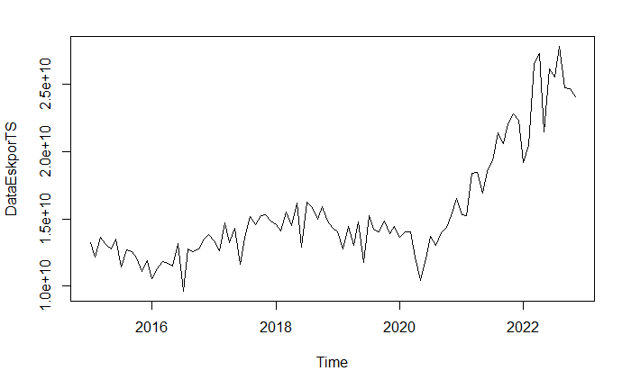

```r
plot.ts(DataEskporTS)
```

5. Akan di cek apakah data Stasioner? Dilakukan dengan uji Dicky-Fuller H0 = Data non-stationer H1 = Data Stasioner a = 0,05 dan p-value = 0.9591, karena p-value > a maka Terima H0 (Data non-s)

```r
adf.test(DataEskporTS)
```

```
    Augmented Dickey-Fuller Test

data:  DataEskporTS
Dickey-Fuller = -0.79348, Lag order = 4, p-value = 0.9591
alternative hypothesis: stationary
```

*Jadi Data belum Stasioner

6. Pengecekan Plot ACF dan PACF pada orde ke-0

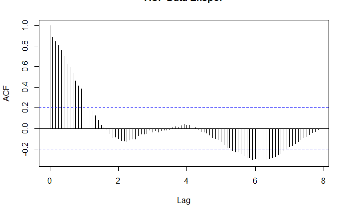

```r
#Plot ACF orde ke-0
acf(DataEskporTS,lag.max= 100, main="ACF Data Ekspor")
```

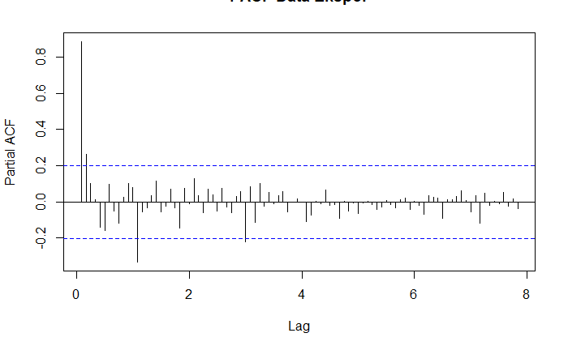

```r
pacf(DataEskporTS,lag.max= 100, main="PACF Data Ekspor")
```

7. Dikarenakan data belum stasioner, dilakukan Transformasi Box-Cox agar Varians menjadi Stasioner (lambda negatif sehingga harus di transformasi)

```r
trans <- BoxCox.lambda(DataEskporTS)
trans
```

```
[1] -0.6132826
```

```r
trans.DE<- BoxCox(DataEskporTS, lambda= trans)
trans.DE
```

```
          Jan      Feb      Mar      Apr      May      Jun      Jul      Aug      Sep      Oct      Nov      Dec
2015 1.630569 1.630569 1.630569 1.630569 1.630569 1.630569 1.630568 1.630569 1.630569 1.630569 1.630568 1.630569
2016 1.630568 1.630568 1.630569 1.630569 1.630568 1.630569 1.630568 1.630569 1.630569 1.630569 1.630569 1.630569
2017 1.630569 1.630569 1.630569 1.630569 1.630569 1.630569 1.630569 1.630569 1.630569 1.630569 1.630569 1.630569
2018 1.630569 1.630569 1.630569 1.630569 1.630569 1.630569 1.630569 1.630569 1.630569 1.630569 1.630569 1.630569
2019 1.630569 1.630569 1.630569 1.630569 1.630569 1.630569 1.630569 1.630569 1.630569 1.630569 1.630569 1.630569
2020 1.630569 1.630569 1.630569 1.630569 1.630568 1.630569 1.630569 1.630569 1.630569 1.630569 1.630569 1.630569
2021 1.630569 1.630569 1.630569 1.630569 1.630569 1.630569 1.630569 1.630569 1.630569 1.630569 1.630569 1.630569
2022 1.630569 1.630569 1.630569 1.630569 1.630569 1.630569 1.630569 1.630569 1.630569 1.630569 1.630569
```

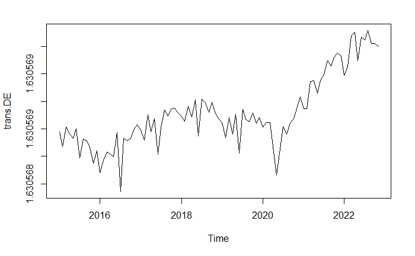

```r
plot.ts(trans.DE)
```

```r
BoxCox.lambda(trans.DE)
```

```
[1] 1.999924
```

8. Dekomposisi Data

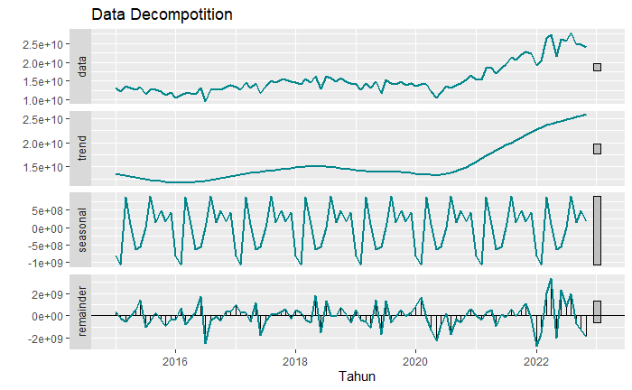

```r
#Plot Dekomposisi Data
DE.stl<-stl(DataEskporTS, s.window = "periodic")
library(ggplot2)
library(forecast)
autoplot(DE.stl)+
  geom_line(col=c("#00868B"), size=1)+
  labs(x="Tahun",
       title="Data Decompotition")
```

*Data terindikasi Mempunya pola trend dan juga musiman, sehingga akan digunakan model SARIMA

9. Differencing dan pengujian stasioneritas

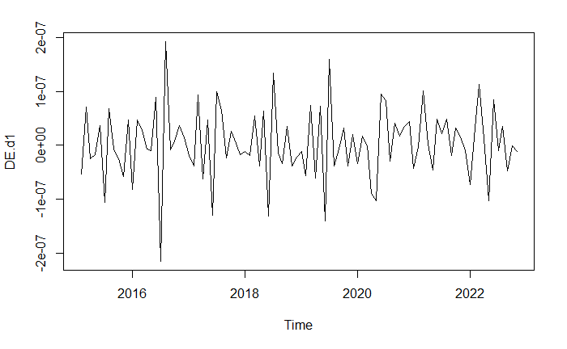

```r
DE.d1 <- diff(trans.DE, lag=1)
plot.ts(DE.d1)
```

```r
adf.test(DE.d1)
```

```
p-value smaller than printed p-value
```

```
    Augmented Dickey-Fuller Test

data:  DE.d1
Dickey-Fuller = -4.8099, Lag order = 4, p-value = 0.01
alternative hypothesis: stationary
```

*Berdasarkan Uji Dickey-Fuller data setelah di differencing sudah stasioner

10. Cek Plot ACF dan PACF data

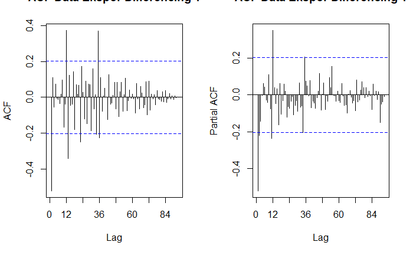

```r
par(mfrow=c(1,2))
Acf(DE.d1,lag.max= 100, main="ACF Data Ekspor Differencing 1")
Pacf(DE.d1,lag.max= 100, main="ACF Data Ekspor Differencing 1")
```

11. Karena Data Musiman ada pada lag 12, maka dilakukan differencing pada lag 12 untuk differencing data 1

[figure not shown]

```r
par(mfrow=c(1,2))
DEd1.d12 <- diff(DE.d1, lag= 12)
Acf(DEd1.d10, lag.max=100)
Pacf(DEd1.d10, lag.max=100)
```

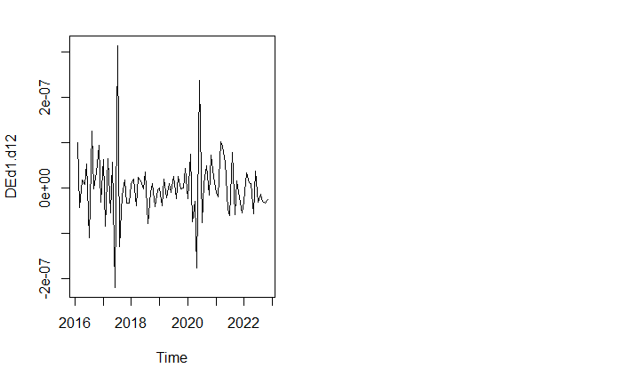

```r
plot.ts(DEd1.d12)
```

```r
adf.test(DEd1.d12)
```

```
    Augmented Dickey-Fuller Test

data:  DEd1.d12
Dickey-Fuller = -3.9122, Lag order = 4, p-value = 0.01782
alternative hypothesis: stationary
```

Model yang mungkin yaitu PACF cutoff di lag 1, ACF cutoff di lag 1 dan 2, musimannya cutoff after lag 12 (sehingga ada 3 kemungkinan dari arima awal. Sehingga kemungkinannya ARIMA(1,1,1)(0,1,1) atau ARIMA(1,1,1)(1,1,0) atau ARIMA(1,1,1)(1,1,1) ARIMA(1,1,2)(0,1,1) atau ARIMA(1,1,2)(1,1,0) atau ARIMA(1,1,2)(1,1,1)

12. DIAGNOSTIC CHECK (Asumsi Cek) MOdel 1

```r
fit1 <- arima(DataEskporTS, order=c(1,1,1), seasonal=list(order=c(0,1,1),period=12), method="ML")
fit1
```

```
Call:
arima(x = DataEskporTS, order = c(1, 1, 1), seasonal = list(order = c(0, 1,
    1), period = 12), method = "ML")

Coefficients:
          ar1      ma1    sma1
      -0.3390  -0.1233  -0.059
s.e.   0.2605   0.2851   0.150

sigma^2 estimated as 2.147e+18:  log likelihood = -1847.12,  aic = 3702.23
```

```r
#1. Uji Kesignifikanan parameter: uji t
coeftest(fit1)
```

```
z test of coefficients:

      Estimate Std. Error z value Pr(>|z|)
ar1  -0.339021   0.260533 -1.3013   0.1932
ma1  -0.123299   0.285080 -0.4325   0.6654
sma1 -0.058967   0.149963 -0.3932   0.6942
```

```r
#2. Uji Pengujian residual apakah white Noise
Box.test(fit1$residuals, type="Ljung")
```

```
    Box-Ljung test

data:  fit1$residuals
X-squared = 0.00023023, df = 1, p-value = 0.9879
```

```r
#3. Pengujian Residual apakah berdistribusi normal
shapiro.test(fit1$residuals)
```

```
    Shapiro-Wilk normality test

data:  fit1$residuals
W = 0.94222, p-value = 0.0003873
```

Model 2

```r
fit2 <- arima(DataEskporTS, order=c(1,1,1), seasonal=list(order=c(1,1,0),period=12), method="ML")
fit2
```

```
Call:
arima(x = DataEskporTS, order = c(1, 1, 1), seasonal = list(order = c(1, 1,
    0), period = 12), method = "ML")

Coefficients:
          ar1      ma1     sar1
      -0.3412  -0.1188  -0.0454
s.e.   0.2627   0.2872   0.1284

sigma^2 estimated as 2.148e+18:  log likelihood = -1847.13,  aic = 3702.27
```

```r
#1. Uji Kesignifikanan parameter: uji t
coeftest(fit2)
```

```
z test of coefficients:

      Estimate Std. Error z value Pr(>|z|)
ar1  -0.341152   0.262682 -1.2987   0.1940
ma1  -0.118803   0.287242 -0.4136   0.6792
sar1 -0.045391   0.128425 -0.3534   0.7238
```

```r
#2. Uji Pengujian residual apakah white Noise
Box.test(fit2$residuals, type="Ljung")
```

```
    Box-Ljung test

data:  fit2$residuals
X-squared = 0.00019135, df = 1, p-value = 0.989
```

```r
#3. Pengujian Residual apakah berdistribusi normal
shapiro.test(fit2$residuals)
```

```
    Shapiro-Wilk normality test

data:  fit2$residuals
W = 0.94175, p-value = 0.0003626
```

Model3

```r
fit3 <- arima(DataEskporTS, order=c(1,1,1), seasonal=list(order=c(1,1,1),period=12), method="ML")
fit3
```

```
Call:
arima(x = DataEskporTS, order = c(1, 1, 1), seasonal = list(order = c(1, 1,
    1), period = 12), method = "ML")

Coefficients:
          ar1      ma1    sar1     sma1
      -0.2432  -0.2241  0.7391  -0.9995
s.e.   0.2511   0.2592  0.1655   0.4547

sigma^2 estimated as 1.886e+18:  log likelihood = -1846,  aic = 3701.99
```

```r
#1. Uji Kesignifikanan parameter: uji t
coeftest(fit3)
```

```
z test of coefficients:

     Estimate Std. Error z value Pr(>|z|)
ar1  -0.24317    0.25111 -0.9684  0.33285
ma1  -0.22408    0.25924 -0.8644  0.38738
sar1  0.73908    0.16545  4.4671 7.93e-06 ***
sma1 -0.99953    0.45470 -2.1982  0.02793 *
---
Signif. codes:  0 ‘***’ 0.001 ‘**’ 0.01 ‘*’ 0.05 ‘.’ 0.1 ‘ ’ 1
```

```r
#2. Uji Pengujian residual apakah white Noise
Box.test(fit3$residuals, type="Ljung")
```

```
    Box-Ljung test

data:  fit3$residuals
X-squared = 0.0059494, df = 1, p-value = 0.9385
```

```r
#3. Pengujian Residual apakah berdistribusi normal
shapiro.test(fit3$residuals)
```

```
    Shapiro-Wilk normality test

data:  fit3$residuals
W = 0.94454, p-value = 0.0005354
```

Model4

```r
fit4 <- arima(DataEskporTS, order=c(1,1,2), seasonal=list(order=c(0,1,1),period=12), method="ML")
fit4
```

```
Call:
arima(x = DataEskporTS, order = c(1, 1, 2), seasonal = list(order = c(0, 1,
    1), period = 12), method = "ML")

Coefficients:
          ar1     ma1      ma2     sma1
      -0.7648  0.3146  -0.1997  -0.0555
s.e.   0.2813  0.3095   0.1811   0.1504

sigma^2 estimated as 2.128e+18:  log likelihood = -1846.77,  aic = 3703.54
```

```r
#1. Uji Kesignifikanan parameter: uji t
coeftest(fit4)
```

```
z test of coefficients:

      Estimate Std. Error z value Pr(>|z|)
ar1  -0.764785   0.281286 -2.7189  0.00655 **
ma1   0.314617   0.309470  1.0166  0.30933
ma2  -0.199718   0.181094 -1.1028  0.27010
sma1 -0.055509   0.150416 -0.3690  0.71210
---
Signif. codes:  0 ‘***’ 0.001 ‘**’ 0.01 ‘*’ 0.05 ‘.’ 0.1 ‘ ’ 1
```

```r
#2. Uji Pengujian residual apakah white Noise
Box.test(fit4$residuals, type="Ljung")
```

```
    Box-Ljung test

data:  fit4$residuals
X-squared = 0.0045009, df = 1, p-value = 0.9465
```

```r
#3. Pengujian Residual apakah berdistribusi normal
shapiro.test(fit4$residuals)
```

```
    Shapiro-Wilk normality test

data:  fit4$residuals
W = 0.9536, p-value = 0.002011
```

Model 5

```r
fit5 <- arima(DataEskporTS, order=c(1,1,2), seasonal=list(order=c(1,1,0),period=12), method="ML")
fit5
```

```
Call:
arima(x = DataEskporTS, order = c(1, 1, 2), seasonal = list(order = c(1, 1,
    0), period = 12), method = "ML")

Coefficients:
          ar1     ma1      ma2     sar1
      -0.7581  0.3093  -0.1949  -0.0422
s.e.   0.2820  0.3102   0.1784   0.1280

sigma^2 estimated as 2.13e+18:  log likelihood = -1846.78,  aic = 3703.57
```

```r
#1. Uji Kesignifikanan parameter: uji t
coeftest(fit5)
```

```
z test of coefficients:

      Estimate Std. Error z value Pr(>|z|)
ar1  -0.758101   0.282041 -2.6879  0.00719 **
ma1   0.309341   0.310178  0.9973  0.31862
ma2  -0.194850   0.178429 -1.0920  0.27482
sar1 -0.042219   0.128032 -0.3298  0.74159
---
Signif. codes:  0 ‘***’ 0.001 ‘**’ 0.01 ‘*’ 0.05 ‘.’ 0.1 ‘ ’ 1
```

```r
#2. Uji Pengujian residual apakah white Noise
Box.test(fit5$residuals, type="Ljung")
```

```
    Box-Ljung test

data:  fit5$residuals
X-squared = 0.0033449, df = 1, p-value = 0.9539
```

```r
#3. Pengujian Residual apakah berdistribusi normal
shapiro.test(fit5$residuals)
```

```
    Shapiro-Wilk normality test

data:  fit5$residuals
W = 0.95302, p-value = 0.001841
```

Model6

```r
fit6 <- arima(DataEskporTS, order=c(1,1,2), seasonal=list(order=c(1,1,1),period=12), method="ML")
fit6
```

```
Call:
arima(x = DataEskporTS, order = c(1, 1, 2), seasonal = list(order = c(1, 1,
    1), period = 12), method = "ML")

Coefficients:
          ar1     ma1      ma2    sar1     sma1
      -0.8063  0.3505  -0.2462  0.7355  -0.9994
s.e.   0.2884  0.3159   0.1906  0.1646   0.4106

sigma^2 estimated as 1.864e+18:  log likelihood = -1845.55,  aic = 3703.1
```

```r
#1. Uji Kesignifikanan parameter: uji t
coeftest(fit6)
```

```
z test of coefficients:

     Estimate Std. Error z value  Pr(>|z|)
ar1  -0.80635    0.28844 -2.7955  0.005181 **
ma1   0.35054    0.31585  1.1098  0.267083
ma2  -0.24624    0.19063 -1.2918  0.196441
sar1  0.73546    0.16461  4.4680 7.896e-06 ***
sma1 -0.99943    0.41057 -2.4342  0.014923 *
---
Signif. codes:  0 ‘***’ 0.001 ‘**’ 0.01 ‘*’ 0.05 ‘.’ 0.1 ‘ ’ 1
```

```r
#2. Uji Pengujian residual apakah white Noise
Box.test(fit6$residuals, type="Ljung")
```

```
    Box-Ljung test

data:  fit6$residuals
X-squared = 0.0096699, df = 1, p-value = 0.9217
```

```r
#3. Pengujian Residual apakah berdistribusi normal
shapiro.test(fit6$residuals)
```

```
    Shapiro-Wilk normality test

data:  fit6$residuals
W = 0.95546, p-value = 0.002668
```

Sehingga kita dapatkan model yang dipakai adalah SARIMA(1,1,1)(1,1,1)[12]

13. FORECASTING

```r
Forecasting <- forecast(DataEskporTS, model=fit3, h=13)
Forecasting
```

|  | Point Forecast | Lo 80 | Hi 80 | Lo 95 | Hi 95 |
| --- | --- | --- | --- | --- | --- |
| Dec 2022 | 24500985609 | 22673334987 | 26328636231 | 21705835190 | 27296136027 |
| Jan 2023 | 21606866898 | 19536577207 | 23677156588 | 18440632046 | 24773101749 |
| Feb 2023 | 22600786211 | 20218714004 | 24982858417 | 18957721149 | 26243851272 |
| Mar 2023 | 27758148152 | 25122566642 | 30393729663 | 23727374067 | 31788922238 |
| Apr 2023 | 28281924158 | 25410323433 | 31153524883 | 23890189833 | 32673658483 |
| May 2023 | 23553636691 | 20465091857 | 26642181524 | 18830114984 | 28277158398 |
| Jun 2023 | 27301450832 | 24009980831 | 30592920833 | 22267581863 | 32335319801 |
| Jul 2023 | 26822130725 | 23339596936 | 30304664514 | 21496054908 | 32148206542 |
| Aug 2023 | 28871829542 | 25208170528 | 32535488556 | 23268746597 | 34474912486 |
| Sep 2023 | 26321885727 | 22485642243 | 30158129211 | 20454857614 | 32188913841 |

[output cut: 3 more lines]

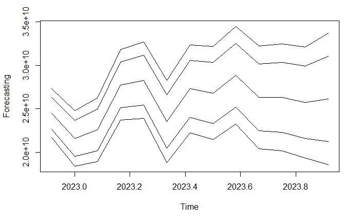

```r
plot.ts(Forecasting)
```

14. Visualisasi

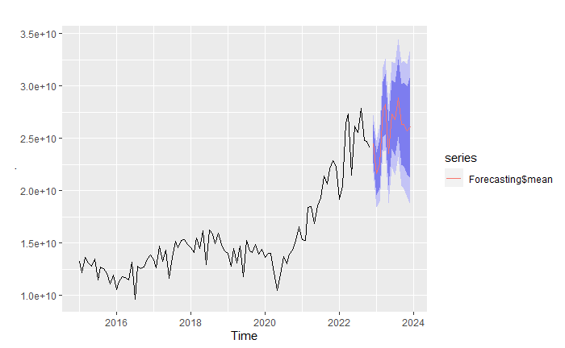

```r
DataEskporTS %>%
   autoplot()+
   autolayer(Forecasting)+
   autolayer(Forecasting$mean)
```